# MTH6139 Time Series

Coursework 1

Yingmei Chen

Spring term 2025

# Section 1: Introduction

This project aims to analyze and forecast Bitcoin prices using Meta Prophet. Bitcoin gained significant popularity a few years ago, so let’s gather some price data and forecast it one year ahead. I have two datasets: ‘bitcoinpart’, covering 2016–2020 with approximately three data points per month, and ‘bitcoin’, covering 2015–2020 with daily data points.

# Section 2: Forecasting

**I will now start to run R code and forecast the bitcoin price data**

## 2.1 Part of the Bitcoin price dataset - ‘bitcoinpart’

I have installed the Prophet package using the code `install.packages("prophet")`, and loaded the library using the code `library(prophet)`

```r
# load library

library(prophet)
library(readr)

# load dataset

Bitcoinpart <- read_csv("data/BitcoinPricepart.csv")
head(Bitcoinpart)
```

```
## # A tibble: 6 × 2
##   ds             y
##   <date>     <dbl>
## 1 2016-01-01  434.
## 2 2016-01-15  364.
## 3 2016-01-30  378.
## 4 2016-02-01  373.
## 5 2016-02-15  400.
## 6 2016-02-29  438.
```

```r
# call the prophet function to fit the model

model1 <- prophet(Bitcoinpart)
```

```
## Disabling daily seasonality. Run prophet with daily.seasonality=TRUE to override this.
```

```r
nextyear1 <- make_future_dataframe(model1, periods = 365)
tail(nextyear1)
```

```
##             ds
## 518 2021-05-26
## 519 2021-05-27
## 520 2021-05-28
## 521 2021-05-29
## 522 2021-05-30
## 523 2021-05-31
```

```r
# forecast proper

forecast1 <- predict(model1, nextyear1)
tail(forecast1[c('ds','yhat','yhat_lower','yhat_upper')])
```

```
##             ds     yhat yhat_lower yhat_upper
## 518 2021-05-26 10424.33   7171.559   13393.55
## 519 2021-05-27 11069.53   7981.603   14155.42
## 520 2021-05-28 10664.84   7844.301   13645.56
## 521 2021-05-29 10068.30   6923.767   12935.24
## 522 2021-05-30 10774.42   8077.768   13829.87
## 523 2021-05-31 10976.91   7856.320   14138.16
```

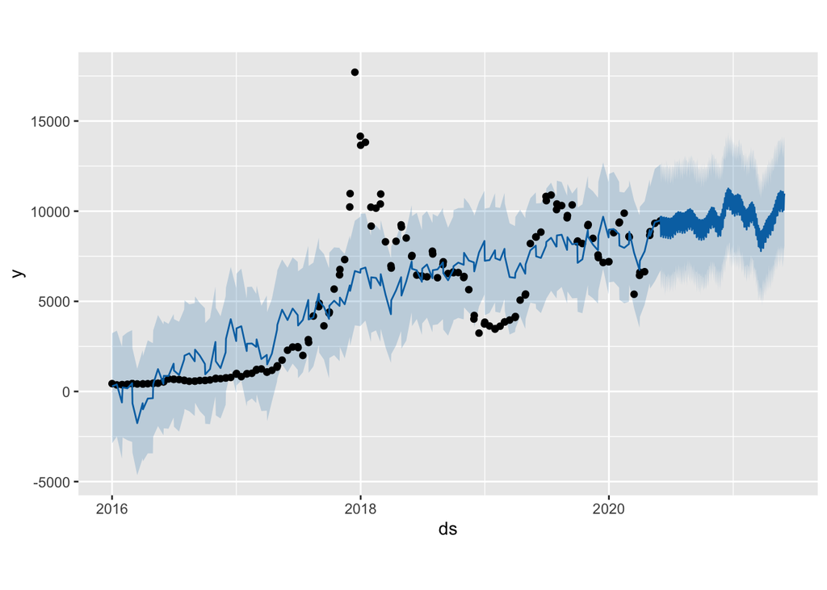

```r
# plot

plot(model1, forecast1)
```

```r
dyplot.prophet(model1, forecast1)
```

[interactive chart not shown]

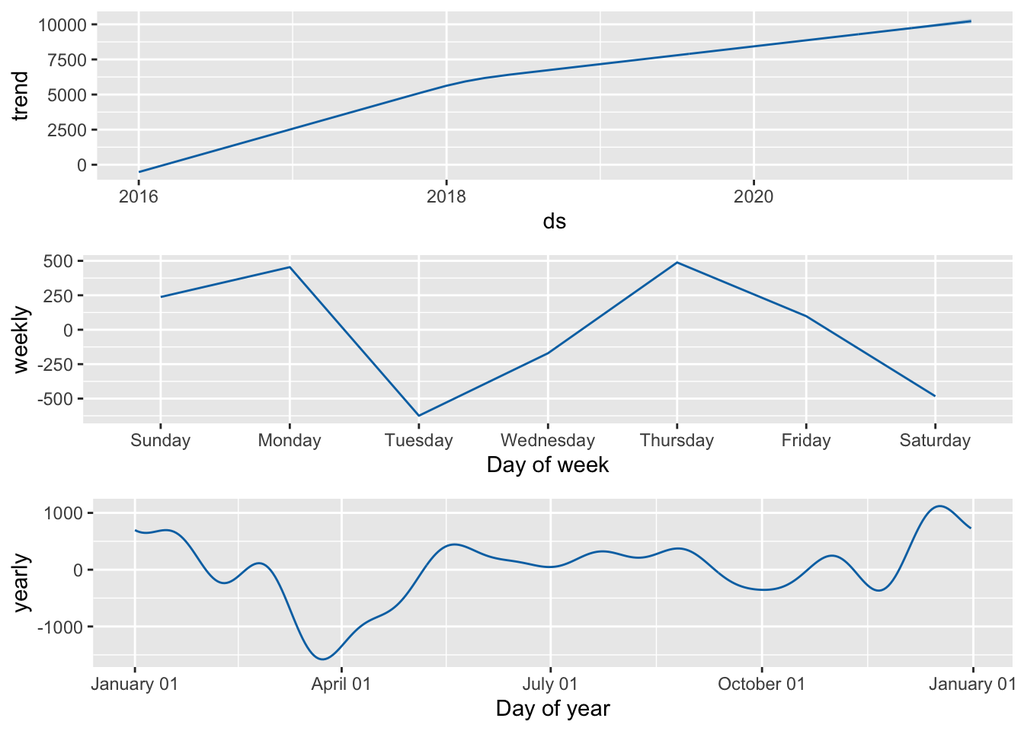

```r
prophet_plot_components(model1, forecast1)
```

The R code above is used to forecast our data one year ahead and generate useful plots to analyze Bitcoin price trends.